# Capstone - Milestone Report

Ian Robinson

10/5/2020

# Overview

We are on a journey to create a predictive text algorithm based on a corpus of three samples of text data. In this milestone report, we will take the first step on this journey. We will load and perform preliminary analysis on our data set, which we have already downloaded and unzipped into our working directory from this link: https://d396qusza40orc.cloudfront.net/dsscapstone/dataset/Coursera-SwiftKey.zip.

We will be working with the US English data files, in the directory data/en-US. The directory contains three large text samples, derived from blogs, news articles, and a sampling of tweets.

## 1. Load the Data

```r
#news.con <- file('en_US_news.txt','rb')
news <- read_lines('en_US_news.txt')#,encoding = 'UTF-8',open='rb')
#blog.con <- file('en_US_blogs.txt','rb')
blog <- read_lines('en_US_blogs.txt')#,encoding='UTF-8')
#twit.con <- file('en_US_twitter.txt','rb')
twitter <- read_lines('en_US_twitter.txt')#,encoding='UTF-8')
#closeAllConnections()
```

## 2. Examine the data sets

We’ll check how many lines and characters each data set has and and how much memory each data set requires.

```r
stri_stats_general(blog)
```

```
##       Lines LinesNEmpty       Chars CharsNWhite
##      899288      899288   206824382   170389539
```

```r
object.size(blog)
```

```
## 267758632 bytes
```

```r
stri_stats_general(news)
```

```
##       Lines LinesNEmpty       Chars CharsNWhite
##     1010242     1010242   203223154   169860866
```

```r
object.size(news)
```

```
## 269840992 bytes
```

```r
stri_stats_general(twitter)
```

```
##       Lines LinesNEmpty       Chars CharsNWhite
##     2360148     2360148   162096031   134082634
```

```r
object.size(twitter)
```

```
## 334484736 bytes
```

Our text samples have millions of lines. As a result, we’ll need to take a sampling of each file and use that to conduct some representative statistical analysis.

## 3. Create Samples

Here we’ll create samples based on a random selection of lines. We’ll take 1% of each sample. To save memory, we’ll remove the full samples once we’ve done this.

```r
set.seed(500)
blogsamp <- blog[rbinom(length(blog),1,.01)==1]
newssamp <- news[rbinom(length(news),1,.01)==1]
twitsamp <- twitter[rbinom(length(twitter),1,.01)==1]
rm(list=c('blog','news','twitter'))
```

## 4. View Samples

```r
head(blogsamp,3)
```

```
## [1] "Due to the nature of my job (raising children) I find my cleaning standards have slipped somewhat. After a day spent washing up, sweeping food off the kitchen floor, wiping all the surfaces, picking up toys and random objects up off every floor in the house, cooking, looking after my kids, m…
## [2] "NIGHT OF THE DRIBBLER"
## [3] "A QUESTION TO ANSWER. Why Isn’t There More Healing? There are many hindrances to receiving healing. We look at just a couple of them."
```

```r
head(newssamp,3)
```

```
## [1] "If Mr. Buffett has a guilty conscience, he can increase donations to charity or simply pay more in taxes. But suggesting we raise the taxes on the wealthy will lead to more problems than it solves."
## [2] "Minnesota at Detroit, 1 p.m."
## [3] "Shakespeare's tragic tale of star-crossed lovers is the only play in Great Lakes history to be staged by all six of the company's permanent artistic directors, beginning with Arthur Lithgow's production in 1963 to Charles Fee's iteration, set in a post-World War I, totalitarian state, curren…
```

```r
head(twitsamp,3)
```

```
## [1] "Doing some #cufon testing and implementation in #wordpress. What the FOUC d'y'all think of cufon?"
## [2] "YourKoz Games+Find out who this is-$2.00+She concentrates on the calibre and quality of education for Jordanian children & global education"
## [3] "Wearing my 2011 shirt to the #Skrillex show in Indy tonight. Already got a lot of compliments."
```

## 5. Preprocess Data

To process the data into a form suitable for analysis, we’ll use tidy principles and the tidytext library. We’ll filter twitter handles, hashtages, email addresses, and punctuation from the data, then we’ll add our three samples into one corpus object. Finally, we’ll process the corpus to remove numbers, strip whitespace, convert everything to lowercase, divide longer strings into individual words, and ensure only alphanumeric characters are represented.

```r
#combine data into data fram of text and source:
alldata <- full_join(data.frame(text=blogsamp,source="blog"),data.frame(text=newssamp,source='news'))
alldata <- alldata %>% full_join(data.frame(text=twitsamp,source='twitter'))
# Remove emails, twitter handles, and hashtags, and replace punctuation characters with spaces

fdata <- alldata %>% mutate(text=gsub('[@][a-zA-Z0-9_]{1,15}','',text)) %>% #twitter handles
  mutate(text = gsub('#\\b[A-Za-z0-9._-]*\\b','',text)) %>% #hashtags
  mutate(text=gsub('\\b[A-Za-z0-9._-]*[@](.*?)[.].{1,3}\\b','',text)) %>% #email addresses
  mutate(text=gsub('<U+.{4}>','',text)) %>% #emoji'
  mutate(text=gsub('[^0-9A-Za-z\' ]','',text)) %>% #anything not alphanumeric or ' or spaces
  mutate(text=removeNumbers(text)) %>% #remove numbers
  mutate(doc_id = row_number()) #keep unique document identifiers

#now we'll split our data set into three tidy tables of unigrams, bigrams, and trigrams:
tidywords <- fdata %>% unnest_tokens(word,text)
tidybis <- fdata %>% unnest_tokens(bigram,text,token='ngrams',n=2)
tidytris <- fdata %>% unnest_tokens(trigram,text,token='ngrams',n=3)
```

## 6. Preliminary Analysis

At last, we’re ready to do some analysis. We’ll start with some analysis of individual words.

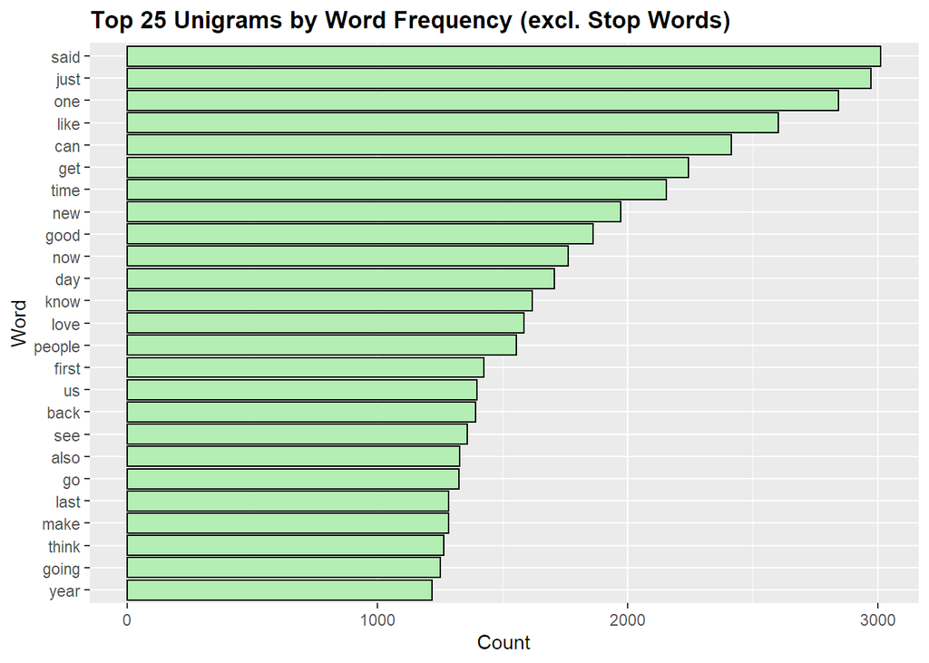

```r
wordfreq <-  tidywords %>% count(word,sort=TRUE)
numwords <- dim(wordfreq)[1]

g <-   ggplot(head(filter(wordfreq,!word %in% get_stopwords()$word),25),
              aes(x = reorder(word,n), y = n)) +
        geom_bar(stat = "identity", fill="darkseagreen2", colour="black") +
        xlab("Word") + ylab("Count") +
        ggtitle("Top 25 Unigrams by Word Frequency (excl. Stop Words)") +
        theme(plot.title = element_text(lineheight=.8, face="bold")) + coord_flip()

print(g)
```

### Histogram

Let’s take a look at a histogram of word frequencies. In this case we’ve taken the log of the frequencies to avoid skewing the histogram too far to the left.

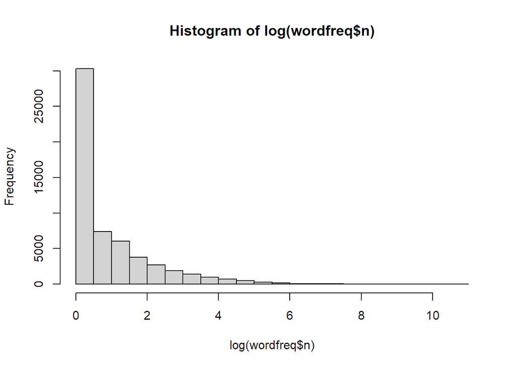

```r
hist(log(wordfreq$n))
```

### Dictionary Coverage

Let’s look at the dictionary coverage. First we’ll calculate what percentage of words in the total corpus are covered by a dictionary of each word size.

```r
coverage = rep(0,numwords)
nwords=sum(wordfreq$n)

for (i in 1:numwords){
  coverage[i] = sum(wordfreq$n[1:i])/nwords
}
wordfreq <- mutate(wordfreq,coverage=coverage)
```

Now let’s plot it:

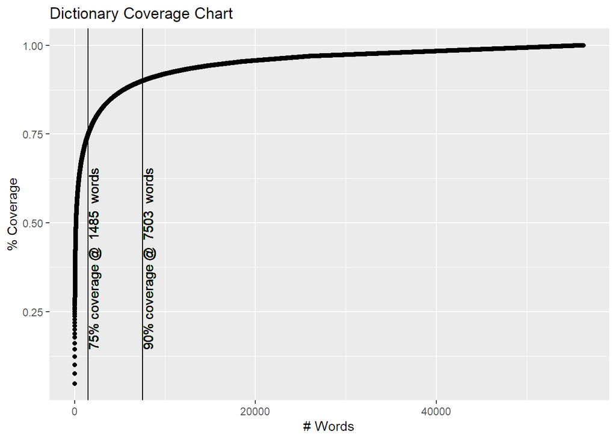

```r
seventyfive= sum(wordfreq$coverage<.75)+1
ninety=sum(wordfreq$coverage <.9)+1
g2 <- qplot(y=coverage,data=wordfreq) +geom_vline(xintercept = seventyfive)+geom_text(aes(x=seventyfive,label=paste('75% coverage @ ',seventyfive,' words'),y=.4),angle=90,vjust=1)+geom_vline(xintercept = ninety) + geom_text(aes(x=ninety,label=paste('90% coverage @ ',ninety,' words'),y=.4),angle=90,vjust=1)    +     xlab("# Words") + ylab("% Coverage") +
        ggtitle("Dictionary Coverage Chart")
print(g2)
```